# EXAMPLE OF USE SYNTHETIC DATA GENERATION PACKAGE

Skills matrix:

$$\\\hspace{1.5cm}Skills \\Students\left(\begin{matrix} 0.5331611 & 0.28072709 & 0.61022624 & 0.7196679 \\ 0.4706583 & 0.68450836 & 0.03774574 & 0.3675002\\ 0.9810095 & 0.24154372 & 0.81285467 & 0.9950425\\ 0.5228266 & 0.09036572 & 0.90412467 & 0.8735288\\ 0.7022250 & 0.28914964 & 0.98592405 & 0.4444356\\ 0.4610726 & 0.72349372 & 0.73188106 & 0.8285151\\ 0.7839393 & 0.83858406 & 0.21673091 & 0.2187936\\ 0.4074115 & 0.35472920 & 0.40375519 & 0.4707774\\ 0.9076050 & 0.93828625 & 0.53785757 & 0.7592005\\ 0.8377285 & 0.61375846 & 0.57157048 & 0.5134974\\ \end{matrix} \right)$$

The probability of the first student to answer the item 4, which involves skills 2,3 and 4, will be the minimum between {0.28072709,0.61022624,0.7196679}, so 0.28072709.

We generate now the correspondent graphs from the returned list:

```
oimage(t(resultMin$skills),xlab='Student', ylab='Skill')
oimage(resultMin$q.matrix,xlab='Item', ylab='Skill')
oimage(t(resultMin$result),xlab='Student', ylab='Item')
```

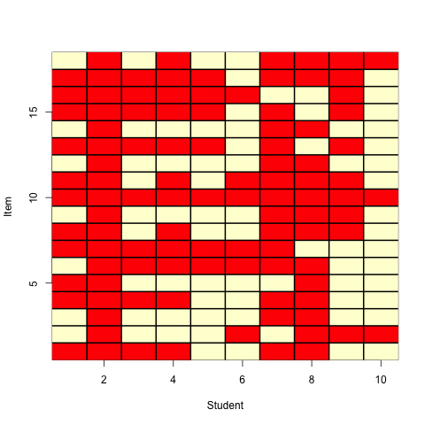

```python
%%R
oimage(t(resultMin$skills),xlab='Student', ylab='Skill')
oimage(resultMin$q.matrix,xlab='Item', ylab='Skill')
oimage(t(resultMin$result),xlab='Student', ylab='Item')
```

In the graphs we can appreciate how the items involving more skills are less succeeded.

The next model used will be similar to the pessimistic approach but in this case we will consider all the values corresponding to the skills involved in an item. The probability of success, instead of being the minimum value, is the root mean square of the corresponding values. It will be better explained with a specific case.

So we generate data according to the root mean square approach using the avgGen() function introducing the correspondent parameters.

```
resultAvg <- avgGen(its = 18,sts = 10,q = qMatrix,skills = skills)
```

```python
%%R
resultAvg <- avgGen(its = 18,sts = 10,q = qMatrix,skills = skills)
```

As we have done for the last explained model, we have this matrices for skills and Q-Matrix:

Q-Matrix:

$$\\\hspace{1.5cm}Items \\Skills\left(\begin{matrix} 0 & 0 & 1 & 0 & 0 & 0 & 0 & 1 & 0 & 1 & 1 & 0 & 0 & 0 & 0 & 1 & 0 & 0\\ 0 & 0 & 0 & 1 & 0 & 1 & 1 & 0 & 0 & 1 & 0 & 0 & 1 & 0 & 1 & 1 & 1 & 1\\ 0 & 1 & 1 & 1 & 0 & 1 & 1 & 1 & 1 & 0 & 1 & 1 & 1 & 1 & 1 & 1 & 0 & 1\\ 1 & 0 & 0 & 1 & 1 & 0 & 1 & 0 & 0 & 1 & 1 & 0 & 1 & 0 & 1 & 1 & 1 & 1\\ \end{matrix} \right)$$

Skills matrix:

$$\\\hspace{1.5cm}Skills \\Students\left(\begin{matrix} 0.5331611 & 0.28072709 & 0.61022624 & 0.7196679 \\ 0.4706583 & 0.68450836 & 0.03774574 & 0.3675002\\ 0.9810095 & 0.24154372 & 0.81285467 & 0.9950425\\ 0.5228266 & 0.09036572 & 0.90412467 & 0.8735288\\ 0.7022250 & 0.28914964 & 0.98592405 & 0.4444356\\ 0.4610726 & 0.72349372 & 0.73188106 & 0.8285151\\ 0.7839393 & 0.83858406 & 0.21673091 & 0.2187936\\ 0.4074115 & 0.35472920 & 0.40375519 & 0.4707774\\ 0.9076050 & 0.93828625 & 0.53785757 & 0.7592005\\ 0.8377285 & 0.61375846 & 0.57157048 & 0.5134974\\ \end{matrix} \right)$$

Given this 2 matrices, the probability of the student 1 to answer right the item 4 will be:

We graphically represent the obtained values.

```
oimage(t(resultAvg$skills),xlab='Student', ylab='Skill')
oimage(resultAvg$q.matrix,xlab='Item', ylab='Skill')
oimage(t(resultAvg$result),xlab='Student', ylab='Item')
```

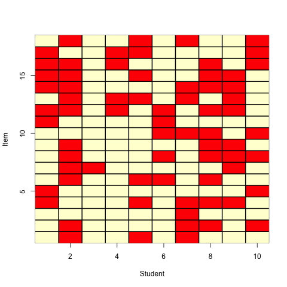

```python
%%R
oimage(t(resultAvg$skills),xlab='Student', ylab='Skill')
oimage(resultAvg$q.matrix,xlab='Item', ylab='Skill')
oimage(t(resultAvg$result),xlab='Student', ylab='Item')
```

As we can see, using this model the students get more correct answers than using the pessimistic approach.

We have already generated data according to linear models, so we will start with more complex models. Some of them don't use neither a skills matrix nor a Q-matrix but, as we will see, they can learn from them to generate the information needed.

That said, the first non-linear models used in this case of use are the DINA/DINO models. That stands for Deterministic Input Noisy And/Or. In those models, the Q-Matrix is used but the skills matrix becomes a skills mastery matrix. To get this skills mastery matrix, we will use the original skills matrix and we will consider a skill as mastered for values above 0.5. So this new matrix is a {0,1} matrix where a 1 means that the student i masters the skill j.

Once it has been explained how this new matrix is obtained, we will go for the DINA (And) model. In this model, if an item requires 2 skills, both must be mastered to succeed it. However, there are two noise parameters that must be explained: the slip and guess factors. On the one hand, even if the 2 skills involved are not mastered, the student will have a probability of answering right the item corresponding to the guess factor. On the other hand, being both skills mastered, there is a probability of failure corresponding to the slip parameter.

The DINO model is very similar to the DINA model but, to succeed an item, the mastery of one of the skills required is enough to succeed an item. The slip and guess noise is also present in this model.

We will generate this data using the dinGen() function. We introduce the parameters used along the document and the skills matrix so that the mastery matrix is generated according to it. We first introduce 'DINA' as model. By default, the slip and guess parameters are setted to 0.2.

```
resultDinA <- dinGen(its = 18,sts = 10, rank = 4 ,q=qMatrix, skills = skills, model = 'DINA')
```

```python
%%R
resultDinA <- dinGen(its = 18,sts = 10, rank = 4 ,q=qMatrix, skills = skills, model = 'DINA')
```

To see how the skills' mastery matrix is generated, we first analize the skills matrix we are working with:

$$\\\hspace{1.5cm}Skills \\Students\left(\begin{matrix} 0.5331611 & 0.28072709 & 0.61022624 & 0.7196679 \\ 0.4706583 & 0.68450836 & 0.03774574 & 0.3675002\\ 0.9810095 & 0.24154372 & 0.81285467 & 0.9950425\\ 0.5228266 & 0.09036572 & 0.90412467 & 0.8735288\\ 0.7022250 & 0.28914964 & 0.98592405 & 0.4444356\\ 0.4610726 & 0.72349372 & 0.73188106 & 0.8285151\\ 0.7839393 & 0.83858406 & 0.21673091 & 0.2187936\\ 0.4074115 & 0.35472920 & 0.40375519 & 0.4707774\\ 0.9076050 & 0.93828625 & 0.53785757 & 0.7592005\\ 0.8377285 & 0.61375846 & 0.57157048 & 0.5134974\\ \end{matrix} \right)$$

Then, we get the mastery matrix generated by the function:

$$\\\hspace{1.5cm}Skills \\Students\left(\begin{matrix} 1 & 0 & 1 & 1\\ 0 & 1 & 0 & 0\\ 1 & 0 & 1 & 1\\ 1 & 0 & 1 & 1\\ 1 & 0 & 1 & 0\\ 0 & 1 & 1 & 1\\ 1 & 1 & 0 & 0\\ 0 & 0 & 0 & 0\\ 1 & 1 & 1 & 1\\ 1 & 1 & 1 & 1\\ \end{matrix} \right)$$

As we can see, values above 0.5 in the original skills matrix become 1's in the new matrix and values under 0.5 become 0's.

Now, looking at the generated matrix and the Q-Matrix, we can see how the DINA model works with a visual representation:

```
oimage(t(resultDinA$skills.mastery),xlab='Student', ylab='Skill')
oimage(resultDinA$q.matrix,xlab='Item', ylab='Skill')
oimage(t(resultDinA$result),xlab='Student', ylab='Item')
```

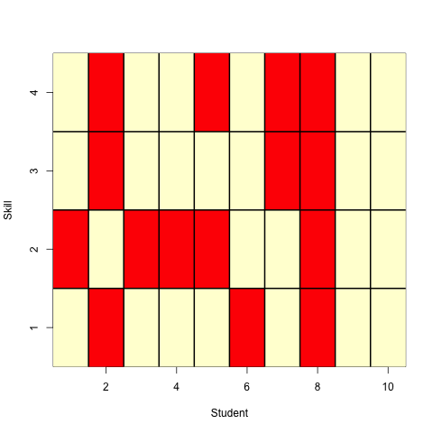

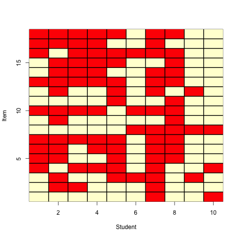

```python
%%R
oimage(t(resultDinA$skills.mastery),xlab='Student', ylab='Skill')
oimage(resultDinA$q.matrix,xlab='Item', ylab='Skill')
oimage(t(resultDinA$result),xlab='Student', ylab='Item')
```

As it can be appreciated in the graphs, the first student answers right to the third item since he masters all the skills required by this item (1 and 3). However, we can see how the slip noise works looking at the student 10, who masters all the skills but there are some items that he hasn't succeed. On the other hand, the student 8 doesn't master any of the skills but he get some rights answers due to the guess parameter.

Once we have seen how the DINA model works, the DINO model doesn't need such a deep explanation. So we proceed to generate data according to this model using also the dinGen() function but switching the model parameter to 'DINO'.

```
resultDinO <- dinGen(its = 18,sts = 10, rank = 4 ,q=qMatrix, skills = skills, model = 'DINO')
```

```python
%%R
resultDinO <- dinGen(its = 18,sts = 10, rank = 4 ,q=qMatrix, skills = skills, model = 'DINO')
```

The skills' mastery matrix is generated in the same way as for DINA so we directly extract the information given by this function.

```
oimage(t(resultDinO$skills.mastery),xlab='Student', ylab='Skill')
oimage(resultDinO$q.matrix,xlab='Item', ylab='Skill')
oimage(t(resultDinO$result),xlab='Student', ylab='Item')
```

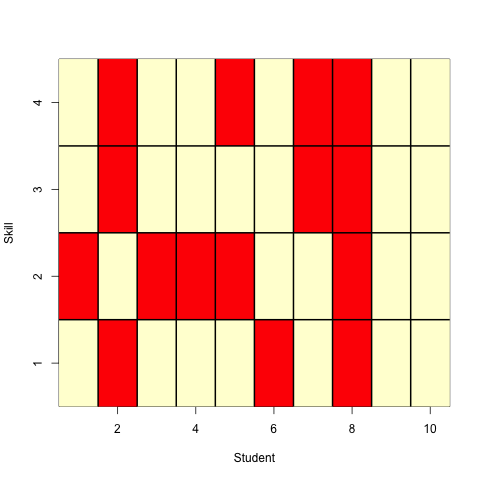

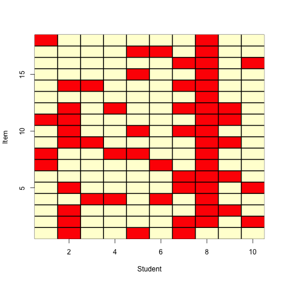

```python
%%R
oimage(t(resultDinO$skills.mastery),xlab='Student', ylab='Skill')
oimage(resultDinO$q.matrix,xlab='Item', ylab='Skill')
oimage(t(resultDinO$result),xlab='Student', ylab='Item')
```

As we could expect, we get a higher average of success than the DINA since the mastery of one of the skills involved is enough to have a strong probability of success. It can also be seen how the slip and guess noise works.

Once we have understood how the DINA/DINO models work, the next model used is IRT. This model doesn't use neither a Q-Matrix nor a skills matrix. But, as we will see, the function used can learn from a results matrix to generate the parameters needed.

As we know, according to the IRT model, the probability of answering right an item $X_{j}$ will depend on an ability factor $\theta$, the item difficulty $b_{j}$ and a discrimination parameter $a_{j}$:

$$P(X_{j}=1 \ |\ \theta) = \frac{1}{1 + e^{-a_{j}(\theta - b_{j})}}$$

So to generate data according to this model we will use the irtGen() function. As it has been mentioned, this function can learn from a results matrix to predict the students' ability factors and the items' difficulties. So we use the results matrix coming from the pessimistic approach, for example. A slip and guess noise is introduced by default with values of 0.2 for both.

```
resultIrtMin <- irtGen(its = 18 ,sts = 10, result = resultMin$results  )
```

```python
%%R
resultIrtMin <- irtGen(its = 18 ,sts = 10, result = resultMin$results  )
```

The way this function generates the parameters needed learning from a results matrix is as follows: The parameters corresponding to the difficulty of each item are generated depending on the success rate of all the students to the corresponding item. Moreover, the single ability of each student is generated depending on the success rate of the corresponding student to all the items. We can see bellow the generated matrices or vectors:

Students' ability:

$$\\\hspace{1.5cm}Students \\Ability\left(\begin{matrix} -0.8888889 & -4 & 0 & -1.333333 & 0.8888889 & 1.333333 & -2.666667 & -2.222222 & -0.4444444 & 2.666667\\ \end{matrix} \right)$$

Items' difficulties:

$$\\\hspace{1.5cm}Items \\Difficulty\left(\begin{matrix} -0.6 & 0 & 1.2 & -0.6 & 1.2 & -1.2 & -1.2 & -0.6 & 0.6 & -3 & -1.2 & 1.2 & -1.2 & 1.2 & -1.2 & -1.2 & -1.8 & -0.6\\ \end{matrix} \right)$$

And the results matrix generated using the IRT model:

```
oimage(t(resultIrtMin$results),xlab='Student', ylab='Item')
```

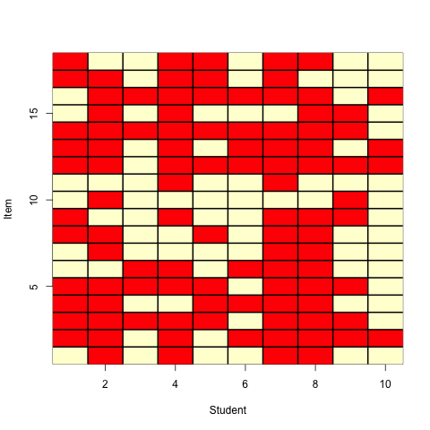

```python
%%R
oimage(t(resultIrtMin$results),xlab='Student', ylab='Item')
```

The last model used is the POKS model (Partial Order Knowledge Structure). In this model a POKS matrix is needed. This matrix will determine the item's knowledge order. So, if there are two related items but one is harder than the other, if a student succeed the most difficult, he will answer right the easiest with a strong probability. Supposing that A and B are connected and A is harder than B, if the student has answered right A, his probability of succeeding B will be: $P(B | A) > p_{1}$.

The first step will be to generate this matrix about the dependencies between items. While building this matrix, there are dependencies that can be represented as trees. An example of a tree would be as follows:

$$\{1\rightarrow2,1\rightarrow3,1\rightarrow4\}$$

As we can see, succeeding the item 1, increase the probability of succeeding 2,3 and 4. There are 3 dependencies and the depth of the tree is 1. However, there can be other kind of trees as the one bellow:

$$\{1\rightarrow2,2\rightarrow3,3\rightarrow4\}$$

In this case, the depth is 3 and indirect dependencies appears since there is a link between the items 1 and 2 and between the items 2 and 3, so there is an indirect dependency between items 1 and 3. So the tree including this dependencies would be as follows:

$$\{1\rightarrow2,1\rightarrow3,1\rightarrow4,2\rightarrow3,2\rightarrow4,3\rightarrow4\}$$

In order to generate this matrix, we will use the poksMatrixGen() function. In this function, we can define the number of independent trees, the total number of dependencies in the matrix and if we want a matrix with indirect dependencies or not. We build a matrix with 15 dependencies, 3 independent trees and indirect dependencies.

```
poks.matrix <- poksMatrixGen(its = 18, depNum = 15 ,trees = 3, indirect.dependencies = TRUE)
```

We plot now the generated matrix.

```
oimage(t(poks.matrix),xlab='Succeeding this item', ylab='Increases probability of succeeding this item')
```

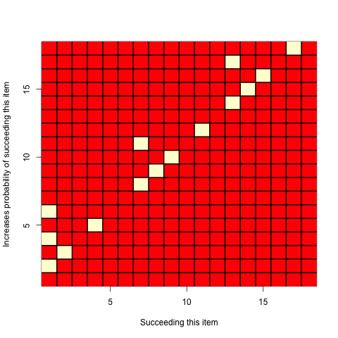

```python
%%R
poks.matrix <- poksMatrixGen(its = 18, depNum = 15 ,trees = 3, indirect.dependencies = TRUE)
oimage(t(poks.matrix),xlab='Succeeding this item', ylab='Increases probability of succeeding this item')
```

In our case, the trees' structure is the next:

$$\{1\rightarrow2,1\rightarrow4,1\rightarrow6,2\rightarrow3,4\rightarrow5\}$$

$$\{7\rightarrow8,7\rightarrow11,8\rightarrow9,9\rightarrow10,11\rightarrow12\}$$

$$\{13\rightarrow14,13\rightarrow17,14\rightarrow15,15\rightarrow16,17\rightarrow18\}$$

Now that we have the POKS matrix, we proceed to generate the results matrix. As it has been explained, succeeding an item will increase the probability of suceeding the related items. However, when there is no information about an item, the probability of a student to suceed this item will depend on his success average, that can be learned, as for the IRT model, from an external results matrix introduced as a parameter. The function used is poksGen(). The results matrix, which the function will learn from to get the success average of the students, is the same as the one used for the IRT model. We set $p_{1}$ to 0.85 and we use the generated poks matrix.

```
resultPoksMin <- poksGen(its = 18,sts = 10,dependencies = poks.matrix,result = resultMin$results,p1 = 0.85)
```

```python
%%R
resultPoksMin <- poksGen(its = 18,sts = 10,dependencies = poks.matrix,result = resultMin$results,p1 = 0.85)
```

We get the graph of the poks' results matrix.

```
oimage(t(resultPoksMin$results),xlab='Students', ylab='Items')
```

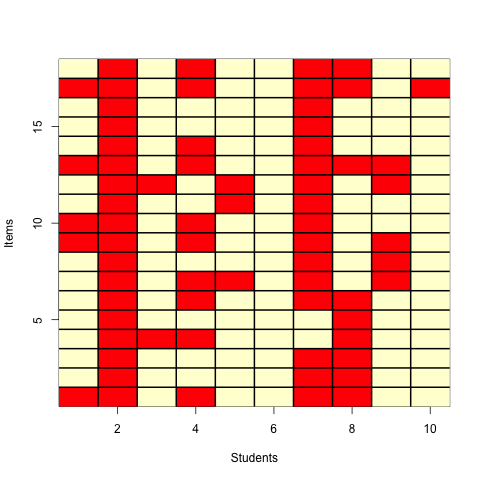

```python
%%R
oimage(t(resultPoksMin$results),xlab='Students', ylab='Items')
```

At this point, we have generated data according to all the models offered by the library. However, this case of use goes a little bit farther. The point now is to analize the predictive performance of each model given an underlying model. That means that, given a results matrix generated according to a specific model, we will see how the rest of models are capable to predict the output.

We are not doing it for all the models but we'll give a couple of clearifying examples. We'll use as underlying models the DINA and DINO. So we first generate the data we need. We will work with a set of 150 students, 200 items, no noise and with a probability ($p_{1}$) of 1 for the POKS. This is not realistic but it will help us to better understand.

We generate a Q-Matrix of 200 items with 4 skills involved:

```
q.matrix <- QgenInc(num.skills = 4, maxSkillsPerItem = 4)
q.matrix <- extendQ(q = q.matrix,extraItems = 185)
```

```
new.skills <- skillsGen(sts = 150,mean = 0,deviation = 1,rank = 4)
```

We generate a POKS matrix with 200 items, 150 dependencies, 7 independent trees and indirect dependencies.

```
new.poks.matrix <- poksMatrixGen(its = 200,depNum = 150,trees = 7,indirect.dependencies = TRUE)
```

We generate now students' performance data for the models that doesn't learn from results matrix:

```
new.resultRand <- randGen(its = 200,sts = 150)
new.resultMin  <- minGen(its = 200, sts = 150,q = q.matrix,skills = new.skills)
new.resultAvg <- avgGen(its = 200, sts = 150, q = q.matrix, skills = new.skills)
new.resultDinA <- dinGen(its = 200,sts = 150, rank = 4 ,q=q.matrix, skills = new.skills, model = 'DINA',guess = rep(0,nrow(q.matrix)))
new.resultDinO <- dinGen(its = 200,sts = 150, rank = 4 ,q=q.matrix, skills = new.skills, model = 'DINO',guess = rep(0,nrow(q.matrix)))
```

```python
%%R
q.matrix <- QgenInc(num.skills = 4, maxSkillsPerItem = 4)
q.matrix <- extendQ(q = q.matrix,extraItems = 185)
new.skills <- skillsGen(sts = 150,mean = 0,deviation = 1,rank = 4)
new.poks.matrix <- poksMatrixGen(its = 200,depNum = 150,trees = 7,indirect.dependencies = TRUE)
new.resultRand <- randGen(its = 200,sts = 150)
new.resultMin  <- minGen(its = 200, sts = 150,q = q.matrix,skills = new.skills)
new.resultAvg <- avgGen(its = 200, sts = 150, q = q.matrix, skills = new.skills)
new.resultDinA <- dinGen(its = 200,sts = 150, rank = 4 ,q=q.matrix, skills = new.skills, model = 'DINA',guess = rep(0,nrow(q.matrix)))
new.resultDinO <- dinGen(its = 200,sts = 150, rank = 4 ,q=q.matrix, skills = new.skills, model = 'DINO',guess = rep(0,nrow(q.matrix)))
```

After this, we generate the first reference of results using the DINA model. This will be the underlying model.

```
referenceDinA <- dinGen(its = 200,sts = 150, rank = 4 ,q=q.matrix, skills = new.skills, model = 'DINA',guess = rep(0,nrow(q.matrix)))
```

As we have mentioned, we don't consider slip and guess noise. We work with the model in its most theoretical form.

```python
%%R
referenceDinA <- dinGen(its = 200,sts = 150, rank = 4 ,q=q.matrix, skills = new.skills, model = 'DINA',guess = rep(0,nrow(q.matrix)))
```

We now analize how each model is capable of predicting the output when the underlying model used is the DINA model. That means that, having a results matrix generated using the DINA model (referenceDinA), our goal is to see how the other models predict these results. To do that, we generate results using the same set of items (same Q-Matrix) and the same students (same skills matrix) and we switch over the different models provided by the SDG library. For the IRT and the POKS, the results matrix which they will learn from is the reference matrix (referenceDinA).

We generate the IRT and POKS results learning from the reference:

```
resultIrtDinA <- irtGen(its = 200 ,sts = 150, result = referenceDinA$results)
resultPoksDinA <- poksGen(its = 200,sts = 150,dependencies = new.poks.matrix,result = referenceDinA$results,p1 = 1)
```

We now analize the predictive performance of each model comparing each results matrix with the reference. We use the compare() function, which compares two matrix returning the percentage of similarity.

```
performanceDinARand <- compare(referenceDinA$result,new.resultRand$result)
performanceDinAMin <- compare(referenceDinA$result,new.resultMin$result)
performanceDinAAvg <- compare(referenceDinA$result,new.resultAvg$result)
performanceDinADinA <- compare(referenceDinA$result,new.resultDinA$result)
performanceDinADinO <- compare(referenceDinA$result,new.resultDinO$result)
performanceDinAIrt <- compare(referenceDinA$result,resultIrtDinA$result)
performanceDinAPoks <- compare(referenceDinA$result,resultPoksDinA$result)
```

```python
%%R
resultIrtDinA <- irtGen(its = 200 ,sts = 150, result = referenceDinA$results)
resultPoksDinA <- poksGen(its = 200,sts = 150,dependencies = new.poks.matrix,result = referenceDinA$results,p1 = 1)
performanceDinARand <- compare(referenceDinA$result,new.resultRand$result)
performanceDinAMin <- compare(referenceDinA$result,new.resultMin$result)
performanceDinAAvg <- compare(referenceDinA$result,new.resultAvg$result)
performanceDinADinA <- compare(referenceDinA$result,new.resultDinA$result)
performanceDinADinO <- compare(referenceDinA$result,new.resultDinO$result)
performanceDinAIrt <- compare(referenceDinA$result,resultIrtDinA$result)
performanceDinAPoks <- compare(referenceDinA$result,resultPoksDinA$result)
```

We generate the labels for each bar and we define de vector of performances of each model.

```
labels <- c("Rand","Min","Avg","DINA","DINO","IRT","POKS")
resultsDinA <- c(performanceDinARand,performanceDinAMin,performanceDinAAvg,performanceDinADinA,performanceDinADinO,performanceDinAIrt,performanceDinAPoks)
```

```python
%%R
labels <- c("Rand","Min","Avg","DINA","DINO","IRT","POKS")
resultsDinA <- c(performanceDinARand,performanceDinAMin,performanceDinAAvg,performanceDinADinA,performanceDinADinO,performanceDinAIrt,performanceDinAPoks)
```

We plot the results in a bar graph using the barComparison() function.

```
barComparison(resultsDinA,labels,col = c('red','blue','green','yellow','violet','brown','grey'))
```

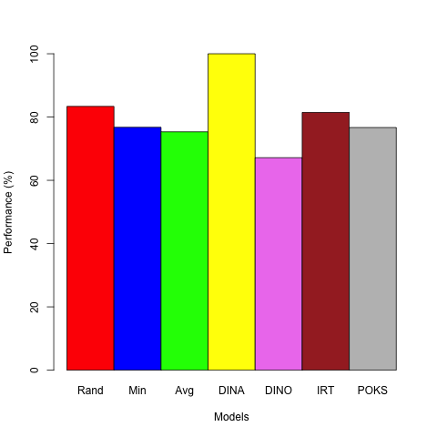

```python
%%R
barComparison(resultsDinA,labels,col = c('red','blue','green','yellow','violet','brown','grey'))
```

It can be appreciated that, as we expected, the performance of the DINA model when the reference data has the same underlying model is 100%, since we haven't introduce any noise.

As we have done for the DINA model, we proceed the same way for the DINO model.

We first generate the reference.

```
referenceDinO <- dinGen(its = 200,sts = 150, rank = 4 ,q=q.matrix, skills = new.skills, model = 'DINO',guess = rep(0,nrow(q.matrix)))
```

```python
%%R
referenceDinO <- dinGen(its = 200,sts = 150, rank = 4 ,q=q.matrix, skills = new.skills, model = 'DINO',guess = rep(0,nrow(q.matrix)))
```

Then the data needed.

IRT and POKS data:

```
resultIrtDinO <- irtGen(its = 200 ,sts = 150, result = referenceDinA$results)
resultPoksDinO <- poksGen(its = 200,sts = 150,dependencies = new.poks.matrix,result = referenceDinA$results,p1 = 1)
```

Performances of each model:

```
performanceDinORand <- compare(referenceDinO$result,new.resultRand$result)
performanceDinOMin <- compare(referenceDinO$result,new.resultMin$result)
performanceDinOAvg <- compare(referenceDinO$result,new.resultAvg$result)
performanceDinODinA <- compare(referenceDinO$result,new.resultDinA$result)
performanceDinODinO <- compare(referenceDinO$result,new.resultDinO$result)
performanceDinOIrt <- compare(referenceDinO$result,resultIrtDinO$result)
performanceDinOPoks <- compare(referenceDinO$result,resultPoksDinO$result)
```

```python
%%R
resultIrtDinO <- irtGen(its = 200 ,sts = 150, result = referenceDinA$results)
resultPoksDinO <- poksGen(its = 200,sts = 150,dependencies = new.poks.matrix,result = referenceDinA$results,p1 = 1)
performanceDinORand <- compare(referenceDinO$result,new.resultRand$result)
performanceDinOMin <- compare(referenceDinO$result,new.resultMin$result)
performanceDinOAvg <- compare(referenceDinO$result,new.resultAvg$result)
performanceDinODinA <- compare(referenceDinO$result,new.resultDinA$result)
performanceDinODinO <- compare(referenceDinO$result,new.resultDinO$result)
performanceDinOIrt <- compare(referenceDinO$result,resultIrtDinO$result)
performanceDinOPoks <- compare(referenceDinO$result,resultPoksDinO$result)
```

We get the performances vector:

```
resultsDinO <- c(performanceDinORand,performanceDinOMin,performanceDinOAvg,performanceDinODinA,performanceDinODinO,performanceDinOIrt,performanceDinOPoks)
```

```python
%%R
resultsDinO <- c(performanceDinORand,performanceDinOMin,performanceDinOAvg,performanceDinODinA,performanceDinODinO,performanceDinOIrt,performanceDinOPoks)
```

And we plot the corresponding graph.

```
barComparison(resultsDinO,labels,col = c('red','blue','green','yellow','violet','brown','grey'))
```

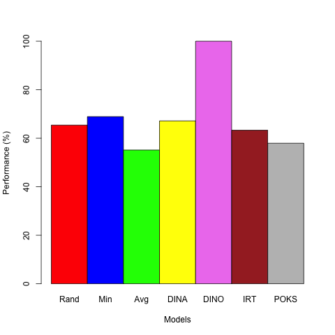

```python
%%R
barComparison(resultsDinO,labels,col = c('red','blue','green','yellow','violet','brown','grey'))
```

As for the DINA model, in this case the predictive performance of the DINO model when the underlying model is DINO is 100%, as we could expect.

However, while generating these graphs, it's not also interesting to see which one predicts the best, but also to see how the rest of models respond. As studied by [Beheshti, B. and Desmarais, M.C. (2014). Assessing Model Fit With Synthetic vs. Real Data. Polytechnique Montreal.] , these kind of graphs could represent a 'signature'. While working with real data we don't know what the underlying model is. So we could analise how the different models predict this data. After this, we could compare the 'signatures' generated using synthethic data, where we know the underlying model, and maybe identify the underlying model of the real data.

In conclusion, we have gone over all the functions provided by the SDG library with specific examples. This general and detailed overview will help to generate synthethic data in order to keep exploring the huge amount of possibilities that this kind of data can contribute to the Educational Data Mining.